# Simple Classifiers & Reverse k-Nearest Neighbours (RkNN)

W tym laboratorium sprawdzimy, jak działają metody ABOD i RkNN do wykrywania punktów odstających (outlierów).

Będziemy:

- generować dane o różnej wymiarowości
- korzystać z rozkładów normalnego i jednostajnego
- liczyć odległości: Euklidesową i KL
- wykrywać outliery różnymi metodami
- porównywać wyniki i robić wizualizacje

Celem jest porównać te podejścia i wyciągnąć wnioski.

```python
import numpy as np

from scipy.spatial.distance import cdist

from scipy.special import rel_entr
from sklearn.neighbors import LocalOutlierFactor

from sklearn.manifold import TSNE
from joblib import Parallel, delayed
import matplotlib.pyplot as plt

np.random.seed(42)

import torch
import gc

# Globalne ustawienia Torch
TORCH_DEVICE = torch.device("cuda" if torch.cuda.is_available() else "cpu")
TORCH_DTYPE = torch.float32
```

### Generowanie danych

Wygenerujemy dane losowe dla trzech wymiarów: 5, 20 i 100.  
Dla każdego wymiaru stworzymy dwa zestawy :

- z rozkładu normalnego (gaussowskiego)
- z rozkładu jednostajnego

Każdy zbiór będzie miał 10 000 punktów.

```python
def generate_datasets(n_samples, n_dimensions) :

    data_normal = np.random.randn(n_samples, n_dimensions)
    data_uniform = np.random.rand(n_samples, n_dimensions)

    return {'normal': data_normal, 'uniform': data_uniform}
```

```python
n_samples = 10_000
dimensions = [5, 20, 100]

datasets = {}
for d in dimensions :
    datasets[d] = generate_datasets(n_samples, d)
```

### Obliczanie macierzy odległości dla wszystkich zbiorów (d=5)

- macierz Euklidesową (symetryczna)
- macierz KL-divergencji (niesymetryczna)

Dla danych normalnych przed użyciem KL wykonujemy przesunięcie,  
aby wszystkie wartości były dodatnie (wymóg KL-divergencji).

```python
def euclidean_distance_matrix(X) :
    X_tensor = torch.tensor(X, dtype=TORCH_DTYPE, device=TORCH_DEVICE)

    X_norm = (X_tensor ** 2).sum(dim=1).reshape(-1, 1)
    D_squared = X_norm + X_norm.T - 2 * X_tensor @ X_tensor.T
    D = torch.sqrt(torch.clamp(D_squared, min=0.0))

    return D.cpu().numpy()


def kl_divergence_matrix(X, row_batch = 250, col_batch = 250) :
    X_tensor = torch.tensor(X, dtype=TORCH_DTYPE, device=TORCH_DEVICE)
    X_tensor = torch.clamp(X_tensor, min=1e-10)
    N = X_tensor.shape[0]

    result = torch.zeros((N, N), dtype=TORCH_DTYPE, device='cpu')

    for i in range(0, N, row_batch):
        x1 = X_tensor[i:i + row_batch].unsqueeze(1)

        row_chunk = []
        for j in range(0, N, col_batch):
            x2 = X_tensor[j:j + col_batch].unsqueeze(0)
            kl = x1 * (x1 / x2).log()
            kl_sum = kl.sum(dim=2).cpu()
            row_chunk.append(kl_sum)

        result[i:i + row_batch] = torch.cat(row_chunk, dim=1)

    return result.numpy()
```

```python
distance_matrices = {}

for d in dimensions :
    print(f"\n== Dimension: {d} ==")
    distance_matrices[d] = {}

    distance_matrices[d]['normal_euclidean'] = euclidean_distance_matrix(datasets[d]['normal'])
    print("-> Euclidean (normal) done")

    distance_matrices[d]['uniform_euclidean'] = euclidean_distance_matrix(datasets[d]['uniform'])
    print("-> Euclidean (uniform) done")

    distance_matrices[d]['uniform_kl'] = kl_divergence_matrix(datasets[d]['uniform'])
    print("-> KL (uniform) done")

    shifted_normal = datasets[d]['normal'] - datasets[d]['normal'].min() + 1e-6
    distance_matrices[d]['normal_kl'] = kl_divergence_matrix(shifted_normal)
    print("-> KL (normal, shifted) done")
```

```
== Dimension: 5 ==
-> Euclidean (normal) done
-> Euclidean (uniform) done
-> KL (uniform) done
-> KL (normal, shifted) done

== Dimension: 20 ==
-> Euclidean (normal) done
-> Euclidean (uniform) done
-> KL (uniform) done
-> KL (normal, shifted) done

== Dimension: 100 ==
-> Euclidean (normal) done
-> Euclidean (uniform) done
-> KL (uniform) done
-> KL (normal, shifted) done
```

## Zadanie 1

### Detekcja outlierów metodą ABOD

Zrobimy to dla danych:

- normalnych (dla metryki Euklidesowej)
- jednostajnych (dla metryki Euklidesowej)

```python
def compute_abod_outliers(data, n_outliers = 10, n_neighbors = 10) :
    lof = LocalOutlierFactor(n_neighbors=n_neighbors, metric='cosine', novelty=False)
    lof.fit(data)
    decision_scores = -lof.negative_outlier_factor_
    return np.argsort(decision_scores)[-n_outliers:]
```

```python
abod_outliers = {}

for d in dimensions :
    abod_outliers[d] = {}
    for dist_type in ['normal', 'uniform']:
        print(f"ABOD -> {dist_type}, d={d}")
        abod_outliers[d][dist_type] = compute_abod_outliers(datasets[d][dist_type])
```

```
ABOD -> normal, d=5
ABOD -> uniform, d=5
ABOD -> normal, d=20
ABOD -> uniform, d=20
ABOD -> normal, d=100
ABOD -> uniform, d=100
```

### Detekcja outlierów metodą k-NN z metrykami Euklidesową i KL

W tym kroku wykryjemy 10 outlierów dla każdej kombinacji:

- rozkład: normalny i jednostajny
- metryka: Euklidesowa i KL-divergencja
- wymiarowość: 5, 20, 100

Dla każdego punktu obliczamy średnią odległość do `k=10` najbliższych sąsiadów.  
Punkty o największej średniej uznajemy za outliery.

```python
def knn_outliers_from_distance_matrix(dist_matrix, k = 10, L = 10) :
    sorted_distances = np.sort(dist_matrix, axis=1)[:, 1:k+1]
    mean_distances = np.mean(sorted_distances, axis=1)
    return np.argsort(mean_distances)[-L:]
```

```python
knn_outliers = {}

for d in dimensions :
    knn_outliers[d] = {}
    for dist_type in ['normal', 'uniform'] :
        print(f"\nKNN -> {dist_type}, d={d}")

        key = f"{dist_type}_euclidean"
        knn_outliers[d][key] = knn_outliers_from_distance_matrix(
            distance_matrices[d][key], k=10, L=10
        )
        print(f"-> k-NN (Euclidean) done")

        key_kl = f"{dist_type}_kl"
        if key_kl in distance_matrices[d] :
            knn_outliers[d][key_kl] = knn_outliers_from_distance_matrix(
                distance_matrices[d][key_kl], k=10, L=10
            )
            print(f"-> k-NN (KL) done")
```

```
KNN -> normal, d=5
-> k-NN (Euclidean) done
-> k-NN (KL) done

KNN -> uniform, d=5
-> k-NN (Euclidean) done
-> k-NN (KL) done

KNN -> normal, d=20
-> k-NN (Euclidean) done
-> k-NN (KL) done

KNN -> uniform, d=20
-> k-NN (Euclidean) done
-> k-NN (KL) done

KNN -> normal, d=100
-> k-NN (Euclidean) done
-> k-NN (KL) done

KNN -> uniform, d=100
-> k-NN (Euclidean) done
-> k-NN (KL) done
```

### Porównanie wyników ABOD i k-NN

Mamy już wykryte outliery z dwóch metod:

- ABOD (analiza kątów)
- k-NN (średnia odległość do najbliższych sąsiadów)

Dla każdej kombinacji (rozkład, wymiarowość, metryka) porównamy:

- które punkty zostały uznane za outliery
- ile mają wspólnych indeksów
- czy obie metody zgadzają się przy różnych wymiarowościach i rozkładach

Pokażemy też wizualizację z t-SNE.

```python
def _tsne_worker(data, outlier_sets, d, dist_type) :
    tsne = TSNE(n_components = 2, perplexity = 50, init = 'pca', random_state = 42)
    reduced = tsne.fit_transform(data)

    labels_array = np.zeros(data.shape[0])
    for method_idx, outliers in enumerate(outlier_sets, start=1) :
        key = f"{dist_type}_euclidean"
        if d in outliers :
            if dist_type in outliers[d] :
                labels_array[outliers[d][dist_type]] = method_idx
            elif key in outliers[d] :
                labels_array[outliers[d][key]] = method_idx

    return reduced, labels_array, f"{dist_type}, d={d}"

def visualize_tsne_grid_multi(datasets, outlier_sets, labels, dimensions, colors=None, n_jobs = 6) :
    num_methods = len(outlier_sets)
    colors = colors or ['lightgray', 'blue', 'red', 'green', 'orange', 'purple'][:num_methods + 1]
    full_labels = ['normal'] + labels

    jobs = [
        delayed(_tsne_worker)(
            datasets[d][dist_type], outlier_sets, d, dist_type
        )
        for dist_type in ['normal', 'uniform']
        for d in dimensions
    ]

    results = Parallel(n_jobs=n_jobs)(jobs)

    _, axes = plt.subplots(nrows=2, ncols=3, figsize=(18, 10))
    plt.subplots_adjust(hspace=0.3, wspace=0.2)

    for idx, (reduced, labels_array, title) in enumerate(results) :
        row_idx = idx // 3
        col_idx = idx % 3
        ax = axes[row_idx, col_idx]

        for value in range(num_methods + 1) :
            ax.scatter(
                reduced[labels_array == value, 0],
                reduced[labels_array == value, 1],
                s=8,
                color=colors[value],
                label=full_labels[value],
                alpha=0.6
            )

        ax.set_title(title)
        ax.set_xticks([])
        ax.set_yticks([])
        if col_idx == 0 :
            ax.legend(loc="upper right", fontsize=8)

    plt.suptitle("t-SNE — porównanie metod wykrywania outlierów (parallel)", fontsize=16)
    plt.show()
```

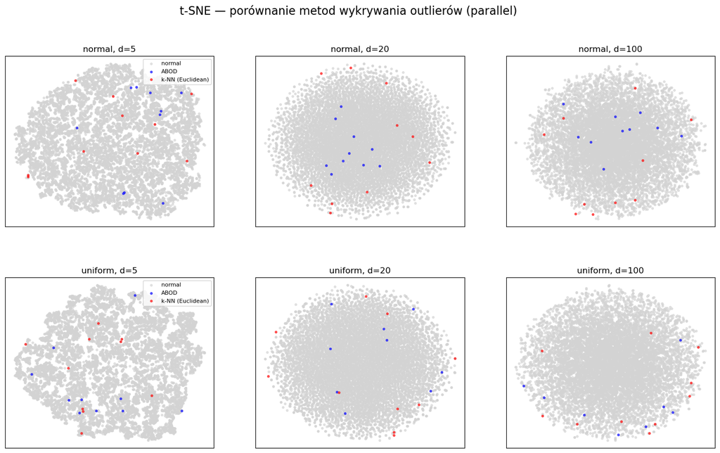

```python
visualize_tsne_grid_multi(
    datasets=datasets,
    outlier_sets=[abod_outliers, knn_outliers],
    labels=['ABOD', 'k-NN (Euclidean)'],
    dimensions=dimensions
)
```

### Wnioski – Task 1 (ABOD i k-NN, metryka Euklidesowa)

Ogólnie: ABOD i k-NN uzupełniają się — warto rozważyć ich połączenie lub wybór zależnie od rodzaju danych (gęstość / rozkład / wymiar).

## Zadanie 2

### Reverse k-NN (RkNN): wykrywanie outlierów jako antihubs

W tym zadaniu wykrywamy outliery jako antihubs, czyli punkty, które:

- najrzadziej pojawiają się w listach k-najbliższych sąsiadów innych punktów

Dla każdego zbioru (normalny, jednostajny), wymiaru (5, 20, 100) i metryki (Euklides, KL):

- sprawdzimy, jak często dany punkt występuje jako sąsiad innych punktów
- wybierzemy 10 punktów o najmniejszej liczbie wystąpień
- porównamy wyniki z metodami ABOD i klasycznym k-NN

```python
def reverse_knn_outliers(dist_matrix, k = 10, L = 10) :
    n = dist_matrix.shape[0]
    rknn_counts = np.zeros(n, dtype=int)

    for i in range(n) :
        neighbor_indices = np.argsort(dist_matrix[i])[1:k+1]
        rknn_counts[neighbor_indices] += 1

    return np.argsort(rknn_counts)[:L]
```

```python
rknn_outliers = {}

for d in dimensions :
    rknn_outliers[d] = {}
    for dist_type in ['normal', 'uniform'] :
        print(f"\nRkNN -> {dist_type}, d={d}")

        key = f"{dist_type}_euclidean"
        rknn_outliers[d][key] = reverse_knn_outliers(
            distance_matrices[d][key], k=10, L=10
        )
        print(f"-> RkNN (Euclidean) done")

        key_kl = f"{dist_type}_kl"
        if key_kl in distance_matrices[d] :
            rknn_outliers[d][key_kl] = reverse_knn_outliers(
                distance_matrices[d][key_kl], k=10, L=10
            )
            print(f"-> RkNN (KL) done")
```

```
RkNN -> normal, d=5
-> RkNN (Euclidean) done
-> RkNN (KL) done

RkNN -> uniform, d=5
-> RkNN (Euclidean) done
-> RkNN (KL) done

RkNN -> normal, d=20
-> RkNN (Euclidean) done
-> RkNN (KL) done

RkNN -> uniform, d=20
-> RkNN (Euclidean) done
-> RkNN (KL) done

RkNN -> normal, d=100
-> RkNN (Euclidean) done
-> RkNN (KL) done

RkNN -> uniform, d=100
-> RkNN (Euclidean) done
-> RkNN (KL) done
```

### Wizualizacja wyników RkNN i porównanie z ABOD oraz klasycznym k-NN

Teraz porównamy wizualnie nowo wykryte outliery z wynikami z Zadania 1 (ABOD i klasyczny k-NN).

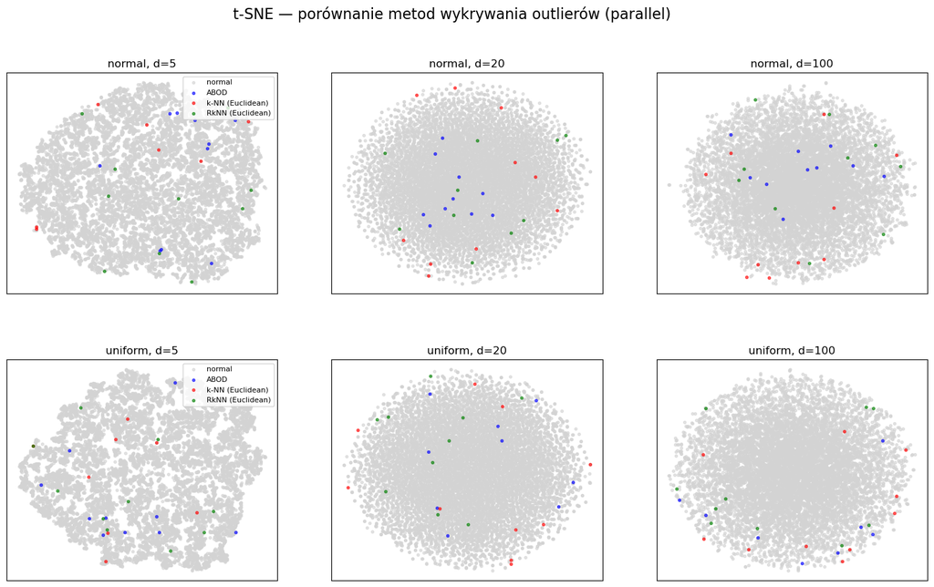

```python
visualize_tsne_grid_multi(
    datasets=datasets,
    outlier_sets=[abod_outliers, knn_outliers, rknn_outliers],
    labels=['ABOD', 'k-NN (Euclidean)', 'RkNN (Euclidean)'],
    dimensions=dimensions
)
```

### Wnioski – Task 2 (RkNN jako antihubs)

- RkNN (zielone punkty) wskazuje outliery, które pojawiają się najrzadziej w listach k-NN innych punktów — są to tzw. antihubs.
- Rozbieżność względem ABOD i k-NN: Antihuby często różnią się od outlierów wskazywanych przez inne metody. Dzieje się tak, ponieważ RkNN nie bazuje na bezpośrednich odległościach, ale na “popularności” punktu.
- Wysoka wymiarowość (d=100): Wskazania RkNN i k-NN zaczynają się częściowo pokrywać, co sugeruje, że przy wysokim d antihubs często są punktami oddalonymi od głównej masy danych.
- Rozkład jednostajny: RkNN wybiera punkty bardziej rozproszone — sugerując, że rozproszenie przestrzenne mocniej wpływa na popularność punktów.
- RkNN jako uzupełnienie: Działa dobrze jako niezależne kryterium wykrywania rzadkich/izolowanych punktów, niekoniecznie pokrywających się z klasycznymi outlierami.

RkNN może wychwytywać inne typy anomalii niż ABOD czy k-NN, mimo iż pokrywa się miejscami z zarówno ABOD jak i k-NN.

## Zadanie 3

### Nowa metoda do wykrywania outlierów

W tym zadaniu mamy stworzyć lub znaleźć inną metodę wykrywania outlierów.  
Przykładową podpowiedzią jest:

- obliczanie średniej odległości każdego punktu do wszystkich innych
- wybranie 10 punktów o największej średniej odległości

W ogólności: jeśli punkt jest odległy od całej reszty — może być outlierem.

(Pierwotnie moim pomysłem było minimal bounding circle i pierwsze 10 punktów które byśmy usunęli zmniejszając okrąg, ale może to być problematyczne i kosztowne obliczeniowo dla zbiorów o dużej wymiarowości, a także problematyczne ze względu na to, że minimal bounding wymaga, aby styczne z n-wymiarową kulą było zawsze n + 1 punktów, więc wprowadza to problem w postaci wyboru których z nich się pozbyć, skoro wszsystkie n + 1 uważamy za jednakowo odległe od barycentrum układu)

```python
def avg_distance_outliers(dist_matrix, L = 10) :
    avg_dists = np.mean(dist_matrix, axis=1)
    return np.argsort(avg_dists)[-L:]
```

```python
avgdist_outliers = {}

for d in dimensions :
    avgdist_outliers[d] = {}
    for dist_type in ['normal', 'uniform'] :
        print(f"\nAvgDist -> {dist_type}, d={d}")

        key = f"{dist_type}_euclidean"
        avgdist_outliers[d][key] = avg_distance_outliers(distance_matrices[d][key])
        print("-> avg dist (Euclidean) done")

        key_kl = f"{dist_type}_kl"
        if key_kl in distance_matrices[d] :
            avgdist_outliers[d][key_kl] = avg_distance_outliers(distance_matrices[d][key_kl])
            print("-> avg dist (KL) done")
```

```
AvgDist -> normal, d=5
-> avg dist (Euclidean) done
-> avg dist (KL) done

AvgDist -> uniform, d=5
-> avg dist (Euclidean) done
-> avg dist (KL) done

AvgDist -> normal, d=20
-> avg dist (Euclidean) done
-> avg dist (KL) done

AvgDist -> uniform, d=20
-> avg dist (Euclidean) done
-> avg dist (KL) done

AvgDist -> normal, d=100
-> avg dist (Euclidean) done
-> avg dist (KL) done

AvgDist -> uniform, d=100
-> avg dist (Euclidean) done
-> avg dist (KL) done
```

### Wizualizacja metody średniej odległości i porównanie z ABOD, k-NN oraz RkNN

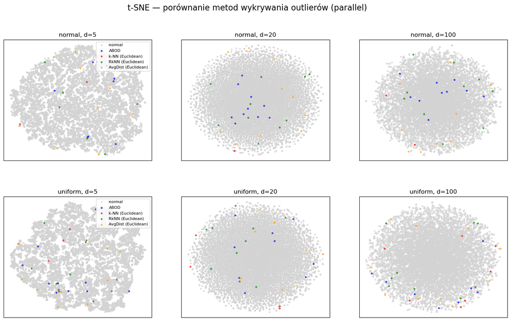

```python
visualize_tsne_grid_multi(
    datasets=datasets,
    outlier_sets=[abod_outliers, knn_outliers, rknn_outliers, avgdist_outliers],
    labels=['ABOD', 'k-NN (Euclidean)', 'RkNN (Euclidean)', 'AvgDist (Euclidean)'],
    dimensions=dimensions
)
```

### Wnioski – Task 3 (metoda AvgDist – średnia odległość do wszystkich punktów)

AvgDist jest prostą, ale skuteczną metodą – może służyć jako bazowa miara “globalnej izolacji”.  
W połączeniu z RkNN (lokalna popularność) i ABOD (analiza kątowa), tworzy komplementarny zestaw podejść do wykrywania outlierów.

### Wnioski końcowe – porównanie metod wykrywania outlierów w przestrzeniach wysokowymiarowych

#### Metody badane:

- ABOD (Angle-Based Outlier Detection)
- k-NN (klasyczny outlier score oparty na odległościach)
- RkNN (Reverse k-NN, antihubs – punkty rzadko pojawiające się jako sąsiedzi)
- AvgDist (średnia odległość do wszystkich punktów)

#### Wpływ wymiarowości:

- Wraz ze wzrostem wymiarów (d=5 → 100), punkty zaczynają wyglądać bardziej „jednorodnie” – efekt klątwy wymiarowości.
- Metody bazujące na klasycznej odległości (k-NN, AvgDist) zaczynają tracić rozróżnialność, ponieważ różnice między odległościami maleją.
- ABOD oraz RkNN lepiej utrzymują kontrasty, ponieważ bazują na bardziej złożonych relacjach (kąty, odwrotna popularność).

#### Rozkład danych:

- W rozkładzie normalnym outliery są zwykle „na zewnątrz” skupiska.
- W rozkładzie jednostajnym, outliery są trudniejsze do uchwycenia – metody bazujące na gęstości (ABOD, RkNN) radzą sobie lepiej.

#### Rekomendacje:

- Każda metoda zachowuje się inaczej i wykrywa różne punkty będące outlierami.
- W praktyce warto łączyć podejścia:
  - ABOD dla danych o strukturze kierunkowej
  - RkNN dla oceny „niepopularności”
  - AvgDist jako szybka ocena globalnej izolacji
- Dobrze jest także wizualizować wyniki i szukać często wskazywanych punktów – mogą to być najbardziej zaufane outliery.